# bulk_excel()

Andrew Ba Tran

March 30, 2017

Creating a single data frame from a folder of similarly structure Excel spreadsheets.

## Description

Like Voltron-ing your data

## Usage

bulk_excel(folder=“DEFAULTBULKCSV2017”, export=“filenamedefaultbulkcsv2017.xls”)

## Arguments

- `folder` - The folder in relation to your working directory where the Excel files exist. Default folder is the current working directory.
- `export` - File name to export CSV file (Not as an Excel file, sorry) as, if wanted.

## Note

This package is based on [**readxl**](https://github.com/tidyverse/readxl), so passing on variables from `read_excel` will work in `bulk_excel`. These variables will apply to the import of each Excel spreadsheet.

### Documentation

In this example, these Excel spreadsheets reside in a folder called **state_data**.

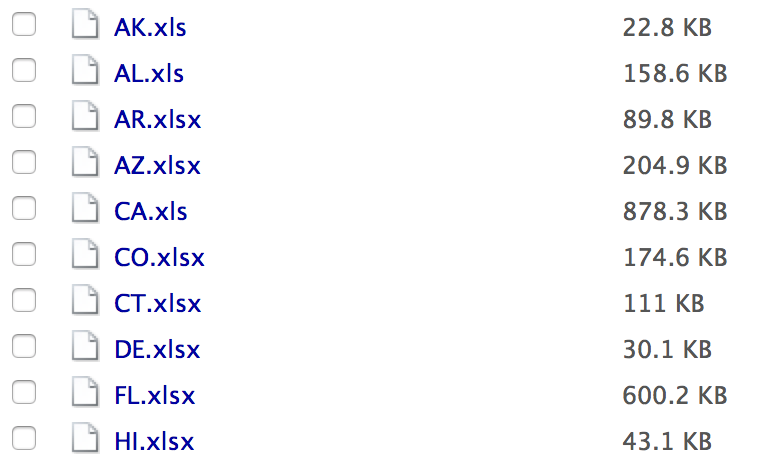

The data structure **must** be similar for each data set, as in column names and data types within the columns are consistent.

Or the bulk join will not work.

To create a new dataframe with all the data sets combined, the command would be:

`combined_data <- bulk_excel(folder="state_data")`

To simply export the data as a new combined CSV file, the command would be:

`bulk_excel(folder="state_data", export="combined_data.csv")`

This would save the file to the current working directory.

You can specify the location to download in `export` as long as you put the folder structure before the CSV file name, like:

`bulk_excel(folder="state_data", export="data_export/combined_data.csv")`